# Warenkorbanalyse: Datenanalyse zum Store Layout Design

## Analyse von häufig zusammen gekaufter Elemente

Mithilfe einer Assoziationsanalyse lässt sich herausfinden welche Produkte häufig zusammen gekauft werden. Aufgrund der herausgefundenen Hierarchie und der grossen Anzahl Produkte scheint es unwahrscheinlich, dass auf Ebene der Produkte viel brauchbares herauskommt.

### Häufig zusammen gekaufte Produkte

Wir benutzen dafür den Apriori Alghorithmus. Dieser sieht vor, dass man zuerst alle Warenkörbe als Set zusammenfasst.

```r
baskets <- orders_to_products %>%
  group_by(orders_id) %>%
  summarise(items = as.vector(list(product_name)))

transactions <- as(baskets$items, "transactions")
```

Mit dem Arules Package für R kann man sich nun den Support ausrechnen und auch plotten lassen. Dieser gibt an, mit welcher Wahrscheinlichkeit ein Produkt in einem Warenkorb landet. Die 30 Produkte mit dem höchsten Support sehen folgendermassen aus:

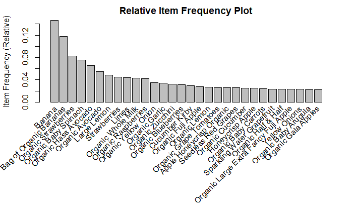

```r
arules::itemFrequencyPlot(transactions,
   topN=30,
   main='Relative Item Frequency Plot',
   type="relative",
   ylab="Item Frequency (Relative)")
```

In Form einer Tabelle sieht das so aus:

```r
item_frequency %>%
  arrange(desc(support)) %>%
  top_n(30)
```

| product_name | support |
| --- | --- |
| Banana | 0.14682571 |
| Bag of Organic Bananas | 0.11802756 |
| Organic Strawberries | 0.08235809 |
| Organic Baby Spinach | 0.07522378 |
| Organic Hass Avocado | 0.06601062 |
| Organic Avocado | 0.05505661 |
| Large Lemon | 0.04805380 |
| Strawberries | 0.04466267 |
| Limes | 0.04383035 |
| Organic Whole Milk | 0.04268065 |

[output cut: 20 more lines]

Die 6 am häufigsten auftretenden Produkte haben eine relative Häufigket von über 5%. Auf Platz 30 sind es schon nur noch knapp über 2%.

Die Ausreisser sind hier “Banana” mit ~14,7% und “Bag of organic Bananas” mit ~11,8%.

Die allgemeine Verteilung des Supports ist folgendermassen:

```r
summary(item_frequency)
```

```
 product_name          support
 Length:49685       Min.   :3.000e-07
 Class :character   1st Qu.:5.380e-06
 Mode  :character   Median :1.883e-05
                    Mean   :2.034e-04
                    3rd Qu.:8.129e-05
                    Max.   :1.468e-01
```

Im Median tritt in ein Produkt nur in 0.0019% der Fälle im Warenkorb auf. Im Durchschnitt sind es 0.02%. Bei 49685 Produkten kann man also sagen, dass die Warenkörbe bis auf einige wenige Ausnahmen ziemlich divers sind. Eine Assoziationsanalyse lohnt sich hier als wahrscheinlich nur bedingt.

```r
quantile(item_frequency$support, c(.9, .95, .98))
```

```
         90%          95%          98%
0.0003185815 0.0007120565 0.0017009859
```

Selbst die 2% der Produkte mit der höchsten Verteilung haben eine minimale relative Häufigkeit von 0.17%. Es muss daher für die Assoziationsanalysie ein niedriger Wert für den Support angenommen werden.

```r
apriori_formatted <- function(transactions, support, confidence, minlen = 2) {
  rules <- apriori(transactions, parameter = list(supp = support, conf = confidence, target="rules", minlen=minlen))
  rules <- rules[!is.redundant(rules)]
  rules_tib <- tibble( lhs = labels( lhs(rules) ),
          rhs = labels( rhs(rules) ),
          support = (quality(rules) %>% pull(support)),
          confidence = (quality(rules) %>% pull(confidence)),
          lift = (quality(rules) %>% pull(lift)),
          count = (quality(rules) %>% pull(count)))
  rules_tib
}
```

```r
products_assoc <- apriori_formatted(transactions, 0.0003, 0.05)
```

```
Apriori

Parameter specification:
```

|  | confidence | minval | smax | arem | aval | originalSupport | maxtime | support | minlen | maxlen | target | ext |
| --- | --- | --- | --- | --- | --- | --- | --- | --- | --- | --- | --- | --- |
|  | 0.05 | 0.1 | 1 | none | FALSE | TRUE | 5 | 3e-04 | 2 | 10 | rules | FALSE |

```
Algorithmic control:
```

|  | filter | tree | heap | memopt | load | sort | verbose |
| --- | --- | --- | --- | --- | --- | --- | --- |
|  | 0.1 | TRUE | TRUE | FALSE | TRUE | 2 | TRUE |

```
Absolute minimum support count: 1003

set item appearances ...[0 item(s)] done [0.01s].
set transactions ...[49685 item(s), 3346083 transaction(s)] done [13.61s].
sorting and recoding items ... [5224 item(s)] done [0.38s].
creating transaction tree ... done [2.82s].
checking subsets of size 1 2 3 4 5 done [4.35s].
writing ... [22347 rule(s)] done [0.04s].
creating S4 object  ... done [0.49s].
```

```r
rules_outed_wconv <- cbind(as(rules_outed, "data.frame"), conviction = interestMeasure(rules, "conviction", transactions))
```

[output not shown]